# Statistical Inference course project - Part 2

Vignesh C Iyer

8/10/2020

## Overview

In this part of the project we’re going to analyze the ToothGrowth data in the R datasets package.

1. Load the ToothGrowth data and perform some basic exploratory data analyses
2. Provide a basic summary of the data.
3. Use confidence intervals and/or hypothesis tests to compare tooth growth by supp and dose. (Only use the techniques from class, even if there’s other approaches worth considering)
4. State your conclusions and the assumptions needed for your conclusions.

Loading the ToothGrowth dataset and preparing it for analysis.

```r
#Loading the ToothGrowth dataset
library(datasets)
data(ToothGrowth)

# Fetching the first few rows
head(ToothGrowth)
```

```
##    len supp dose
## 1  4.2   VC  0.5
## 2 11.5   VC  0.5
## 3  7.3   VC  0.5
## 4  5.8   VC  0.5
## 5  6.4   VC  0.5
## 6 10.0   VC  0.5
```

```r
# Summarizing the dataset
summary(ToothGrowth)
```

```
##       len        supp         dose
##  Min.   : 4.20   OJ:30   Min.   :0.500
##  1st Qu.:13.07   VC:30   1st Qu.:0.500
##  Median :19.25           Median :1.000
##  Mean   :18.81           Mean   :1.167
##  3rd Qu.:25.27           3rd Qu.:2.000
##  Max.   :33.90           Max.   :2.000
```

Further breaking down the dataset for analysis

```r
unique(ToothGrowth$supp)
```

```
## [1] VC OJ
## Levels: OJ VC
```

```r
unique(ToothGrowth$dose)
```

```
## [1] 0.5 1.0 2.0
```

So from the above we get 2 levels of supplements and 3 levels of dose.

- supp = ‘OJ’, ‘VC’
- dose = $0.5, 1,2$

Graphically, we can also use boxplot to provide a quick visual on the impact of dosage and supplement on the tooth growth, see below:

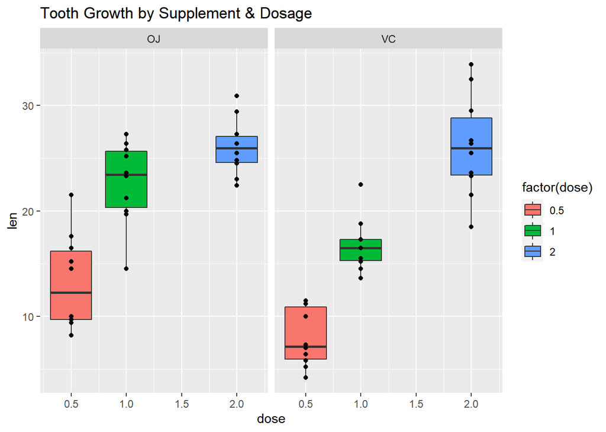

```r
library(ggplot2)
tg_supp_dose <- ggplot(ToothGrowth, aes(x=dose, y=len))
tg_supp_dose <- tg_supp_dose + geom_boxplot(aes(fill=factor(dose)))
tg_supp_dose <- tg_supp_dose + geom_point()
tg_supp_dose <- tg_supp_dose + facet_grid(.~supp)
tg_supp_dose <- tg_supp_dose + ggtitle("Tooth Growth by Supplement & Dosage")
tg_supp_dose
```

## Comparison of Tooth growth based on supplements and dosage

Applying the Hypothesis Testing, we conduct it based on two parameters

- Do the use of supplements really have an impact on the tooth growth?
- Does an increased amount of dosage accelerate teeth growth?

### (a) Hypothesis testing by Supplements

H0 = Both the supplements have the same mean

Ha = The Means are different

```r
t.test(ToothGrowth$len[ToothGrowth$supp == "OJ"],
       ToothGrowth$len[ToothGrowth$supp == "VC"],
       paired = FALSE,
       var.equal = FALSE)
```

```
##
##  Welch Two Sample t-test
##
## data:  ToothGrowth$len[ToothGrowth$supp == "OJ"] and ToothGrowth$len[ToothGrowth$supp == "VC"]
## t = 1.9153, df = 55.309, p-value = 0.06063
## alternative hypothesis: true difference in means is not equal to 0
## 95 percent confidence interval:
##  -0.1710156  7.5710156
## sample estimates:
## mean of x mean of y
##  20.66333  16.96333
```

### (b) Hypothesis testing by Dosage

```r
t.test(ToothGrowth$len[ToothGrowth$dose == 2],
       ToothGrowth$len[ToothGrowth$dose == 1],
       paired = FALSE,
       var.equal = TRUE)
```

```
##
##  Two Sample t-test
##
## data:  ToothGrowth$len[ToothGrowth$dose == 2] and ToothGrowth$len[ToothGrowth$dose == 1]
## t = 4.9005, df = 38, p-value = 1.811e-05
## alternative hypothesis: true difference in means is not equal to 0
## 95 percent confidence interval:
##  3.735613 8.994387
## sample estimates:
## mean of x mean of y
##    26.100    19.735
```